# Installation of Program

|  | season | holiday | workingday | weather | temp | atemp | humidity | windspeed | casual | registered | count | Year | Quater | Quater_ver2 | Month | Day | Hour | DayofWeek |
| --- | --- | --- | --- | --- | --- | --- | --- | --- | --- | --- | --- | --- | --- | --- | --- | --- | --- | --- |
| season | 1 | -0.011 | 0.012 | -0.013 | 0.4 | 0.4 | 0.18 | -0.14 | 0.11 | 0.086 | 0.1 | -0.4 | 0.88 | 0.11 | 0.86 | 0.046 | -0.0074 | -0.0065 |
| holiday | -0.011 | 1 | -0.25 | -0.018 | -0.025 | -0.033 | -0.029 | 0.022 | 0.029 | -0.046 | -0.029 | -0.0016 | 0.024 | 0.014 | 0.0065 | 0.013 | 0.00032 | -0.19 |
| workingday | 0.012 | -0.25 | 1 | 0.053 | 0.056 | 0.061 | 0.028 | 0.0027 | -0.31 | 0.13 | 0.018 | 0.0031 | -0.0072 | -0.0011 | 0.0065 | -0.0024 | 0.0025 | -0.7 |
| weather | -0.013 | -0.018 | 0.053 | 1 | -0.095 | -0.096 | 0.43 | 0.011 | -0.16 | -0.14 | -0.16 | -0.025 | -0.018 | -0.038 | -0.014 | 0.00095 | -0.026 | -0.049 |
| temp | 0.4 | -0.025 | 0.056 | -0.095 | 1 | 0.99 | -0.05 | -0.0091 | 0.46 | 0.35 | 0.42 | -0.055 | 0.31 | 0.13 | 0.34 | 0.086 | 0.14 | -0.038 |
| atemp | 0.4 | -0.033 | 0.061 | -0.096 | 0.99 | 1 | -0.033 | -0.05 | 0.46 | 0.34 | 0.41 | -0.052 | 0.32 | 0.14 | 0.35 | 0.08 | 0.14 | -0.04 |
| humidity | 0.18 | -0.029 | 0.028 | 0.43 | -0.05 | -0.033 | 1 | -0.3 | -0.32 | -0.28 | -0.32 | -0.14 | 0.19 | -0.039 | 0.19 | 0.038 | -0.27 | -0.032 |
| windspeed | -0.14 | 0.022 | 0.0027 | 0.011 | -0.0091 | -0.05 | -0.3 | 1 | 0.08 | 0.1 | 0.11 | 0.056 | -0.13 | -0.022 | -0.14 | 0.0057 | 0.14 | -0.014 |
| casual | 0.11 | 0.029 | -0.31 | -0.16 | 0.46 | 0.46 | -0.32 | 0.08 | 1 | 0.51 | 0.71 | 0.12 | 0.065 | 0.17 | 0.073 | 0.01 | 0.29 | 0.25 |
| registered | 0.086 | -0.046 | 0.13 | -0.14 | 0.35 | 0.34 | -0.28 | 0.1 | 0.51 | 1 | 0.97 | 0.21 | 0.043 | 0.26 | 0.059 | 0.011 | 0.38 | -0.083 |
| count | 0.1 | -0.029 | 0.018 | -0.16 | 0.42 | 0.41 | -0.32 | 0.11 | 0.71 | 0.97 | 1 | 0.21 | 0.054 | 0.27 | 0.07 | 0.012 | 0.4 | 0.0036 |
| Year | -0.4 | -0.0016 | 0.0031 | -0.025 | -0.055 | -0.052 | -0.14 | 0.056 | 0.12 | 0.21 | 0.21 | 1 | -0.45 | 0.83 | -0.44 | 0.00091 | -0.0037 | -0.0013 |
| Quater | 0.88 | 0.024 | -0.0072 | -0.018 | 0.31 | 0.32 | 0.19 | -0.13 | 0.065 | 0.043 | 0.054 | -0.45 | 1 | 0.13 | 0.97 | 0.012 | -0.0066 | 0.0015 |
| Quater_ver2 | 0.11 | 0.014 | -0.0011 | -0.038 | 0.13 | 0.14 | -0.039 | -0.022 | 0.17 | 0.26 | 0.27 | 0.83 | 0.13 | 1 | 0.12 | 0.0085 | -0.0083 | -0.00054 |
| Month | 0.86 | 0.0065 | 0.0065 | -0.014 | 0.34 | 0.35 | 0.19 | -0.14 | 0.073 | 0.059 | 0.07 | -0.44 | 0.97 | 0.12 | 1 | 0.011 | -0.0069 | -0.00048 |
| Day | 0.046 | 0.013 | -0.0024 | 0.00095 | 0.086 | 0.08 | 0.038 | 0.0057 | 0.01 | 0.011 | 0.012 | 0.00091 | 0.012 | 0.0085 | 0.011 | 1 | 0.00073 | -0.014 |
| Hour | -0.0074 | 0.00032 | 0.0025 | -0.026 | 0.14 | 0.14 | -0.27 | 0.14 | 0.29 | 0.38 | 0.4 | -0.0037 | -0.0066 | -0.0083 | -0.0069 | 0.00073 | 1 | -0.003 |
| DayofWeek | -0.0065 | -0.19 | -0.7 | -0.049 | -0.038 | -0.04 | -0.032 | -0.014 | 0.25 | -0.083 | 0.0036 | -0.0013 | 0.0015 | -0.00054 | -0.00048 | -0.014 | -0.003 | 1 |

|  | casual | registered | count |
| --- | --- | --- | --- |
| season | 0.11 | 0.086 | 0.1 |
| holiday | 0.029 | -0.046 | -0.029 |
| workingday | -0.31 | 0.13 | 0.018 |
| weather | -0.16 | -0.14 | -0.16 |
| temp | 0.46 | 0.35 | 0.42 |
| atemp | 0.46 | 0.34 | 0.41 |
| humidity | -0.32 | -0.28 | -0.32 |
| windspeed | 0.08 | 0.1 | 0.11 |
| casual | 1 | 0.51 | 0.71 |
| registered | 0.51 | 1 | 0.97 |
| count | 0.71 | 0.97 | 1 |
| Year | 0.12 | 0.21 | 0.21 |
| Quater | 0.065 | 0.043 | 0.054 |
| Quater_ver2 | 0.17 | 0.26 | 0.27 |
| Month | 0.073 | 0.059 | 0.07 |
| Day | 0.01 | 0.011 | 0.012 |
| Hour | 0.29 | 0.38 | 0.4 |
| DayofWeek | 0.25 | -0.083 | 0.0036 |

|  | casual | registered | count |
| --- | --- | --- | --- |
| season | 0.11 | 0.086 | 0.1 |
| holiday | 0.029 | -0.046 | -0.029 |
| workingday | -0.31 | 0.13 | 0.018 |
| weather | -0.16 | -0.14 | -0.16 |
| temp | 0.46 | 0.35 | 0.42 |
| atemp | 0.46 | 0.34 | 0.41 |
| humidity | -0.32 | -0.28 | -0.32 |
| windspeed | 0.08 | 0.1 | 0.11 |

```
Text(0,0.5,'Demand')
```

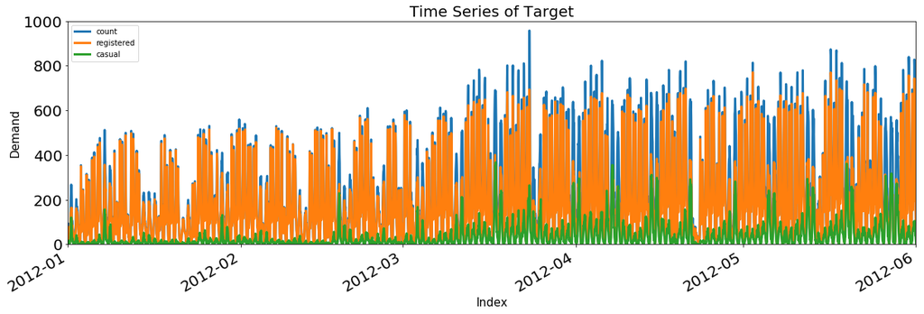

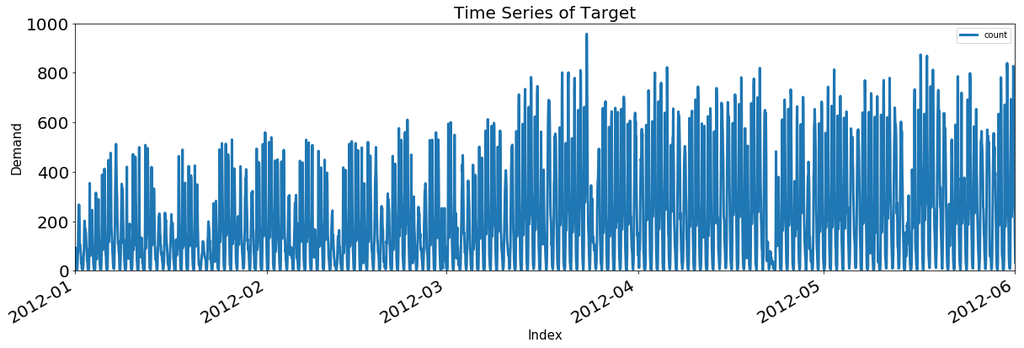

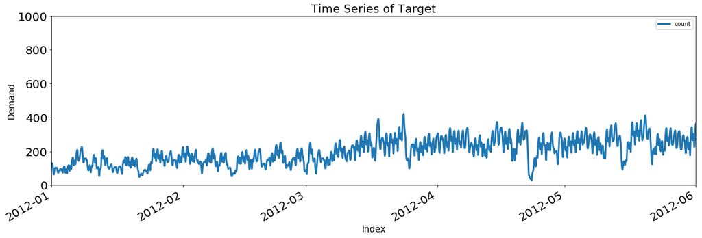

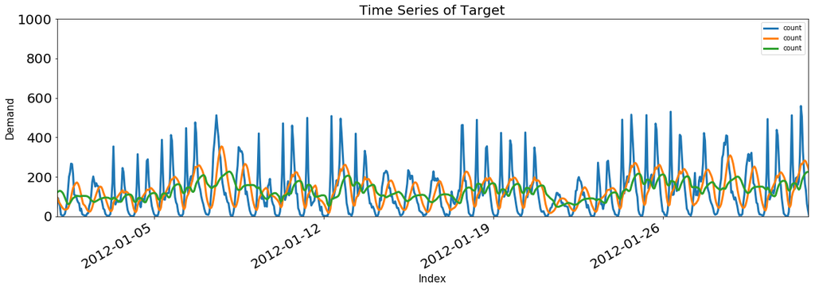

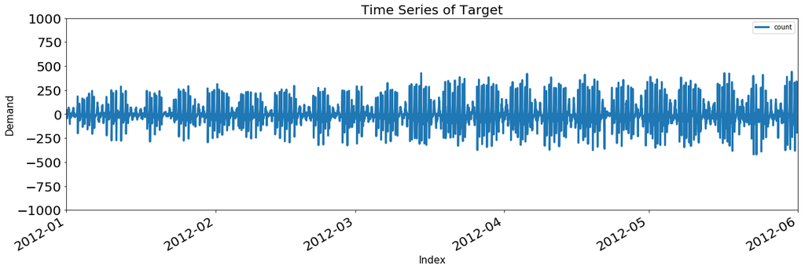

```python
raw_train.corr()
raw_train.corr().style.background_gradient()
raw_train.corr().style.background_gradient().set_precision(2)
display(raw_train.corr().style.background_gradient().set_precision(2).set_properties(**{'font-size': '15pt'}))
raw_train.corr().iloc[:,8:11]
raw_train.corr().loc[:, ['casual', 'registered', 'count']]
display(raw_train.corr().loc[:, ['casual', 'registered', 'count']].style.background_gradient().set_precision(2).set_properties(**{'font-size': '15pt'}))
display(raw_train.corr().iloc[0:8,8:11].style.background_gradient().set_precision(2).set_properties(**{'font-size': '15pt'}))

raw_train[['count','registered','casual']].plot(kind='line', figsize=(20,6), linewidth=3, fontsize=20,
                                               xlim=('2012-01-01', '2012-06-01'), ylim=(0,1000))
plt.title('Time Series of Target', fontsize=20)
plt.xlabel('Index', fontsize=15)
plt.ylabel('Demand', fontsize=15)

raw_train[['count']].plot(kind='line', figsize=(20,6), linewidth=3, fontsize=20,
                                               xlim=('2012-01-01', '2012-06-01'), ylim=(0,1000))
plt.title('Time Series of Target', fontsize=20)
plt.xlabel('Index', fontsize=15)
plt.ylabel('Demand', fontsize=15)

raw_train[['count']].rolling(20).mean().plot(kind='line', figsize=(20,6), linewidth=3, fontsize=20,
                                             xlim=('2012-01-01', '2012-06-01'), ylim=(0,1000))
plt.title('Time Series of Target', fontsize=20)
plt.xlabel('Index', fontsize=15)
plt.ylabel('Demand', fontsize=15)

pd.concat([raw_train[['count']],
           raw_train[['count']].rolling(10).mean(),
           raw_train[['count']].rolling(20).mean()], axis=1).plot(kind='line', figsize=(20,6), linewidth=3, fontsize=20,
                                                                  xlim=('2012-01-01', '2012-02-01'), ylim=(0,1000))
plt.title('Time Series of Target', fontsize=20)
plt.xlabel('Index', fontsize=15)
plt.ylabel('Demand', fontsize=15)

raw_train[['count']].diff().plot(kind='line', figsize=(20,6), linewidth=3, fontsize=20,
                                 xlim=('2012-01-01', '2012-06-01'), ylim=(-1000,1000))
plt.title('Time Series of Target', fontsize=20)
plt.xlabel('Index', fontsize=15)
plt.ylabel('Demand', fontsize=15)
```

# Setting of Analysis

> **1. Import Library**  
> **2. Data Loading** [(Data Source and Description)](https://www.kaggle.com/c/bike-sharing-demand/data)  
> **3. Rearrange of Data**  
> **4. Split of Data: Train, Validate, Test Sets**  
> **5. Descriptive Statistics and Getting Insight from Features**  
> **6. Applying Models**

```python
# Confirm of input and output
drop_column = ['temp_group']
# X_train.drop(columns=drop_column, inplace=True)
# X_test.drop(columns=drop_column, inplace=True)
# or
for sub_col in drop_column:
    if sub_col in X_train.columns:
        X_train.drop(columns=sub_col, inplace=True)
        X_test.drop(columns=sub_col, inplace=True)

from sklearn.linear_model import LinearRegression, Lasso, ElasticNet
from sklearn.kernel_ridge import KernelRidge
from sklearn.ensemble import GradientBoostingRegressor, RandomForestRegressor
from xgboost import XGBRegressor
from lightgbm import LGBMRegressor

# LinearRegression (using sklearn)
model_fit_reg1 = LinearRegression(fit_intercept=True, normalize=False).fit(X_train, Y_train)
# display(pd.concat([pd.DataFrame(X_train.columns, columns=['Features']), pd.DataFrame(model_fit_reg1.coef_, index=['Coefficients']).T], axis=1))
model_pred_tr_reg1 = model_fit_reg1.predict(X_train)
model_pred_te_reg1 = model_fit_reg1.predict(X_test)

# LinearRegression (using statsmodels)
model_fit_reg2 = sm.OLS(Y_train, X_train).fit()
# display(model_fit_reg2.summary())
model_pred_tr_reg2 = model_fit_reg2.predict(X_train)
model_pred_te_reg2 = model_fit_reg2.predict(X_test)

# Lasso
model_fit_reg3 = Lasso(alpha=0.5, fit_intercept=True, normalize=False, random_state=123).fit(X_train, Y_train)
model_pred_tr_reg3 = model_fit_reg3.predict(X_train)
model_pred_te_reg3 = model_fit_reg3.predict(X_test)

# ElasticNet
model_fit_reg4 = ElasticNet(alpha=0.1, l1_ratio=0.1, fit_intercept=True, normalize=False, random_state=123).fit(X_train, Y_train)
model_pred_tr_reg4 = model_fit_reg4.predict(X_train)
model_pred_te_reg4 = model_fit_reg4.predict(X_test)

# GradientBoostingRegression
model_fit_reg5 = GradientBoostingRegressor(alpha=0.1, learning_rate=0.05, loss='huber', criterion='friedman_mse',
                                           n_estimators=1000, random_state=123).fit(X_train, Y_train)
model_pred_tr_reg5 = model_fit_reg5.predict(X_train)
model_pred_te_reg5 = model_fit_reg5.predict(X_test)

# # XGBoost
# model_fit_reg6 = XGBRegressor(learning_rate=0.05, n_estimators=100, random_state=123).fit(X_train, Y_train)
# model_pred_tr_reg6 = model_fit_reg6.predict(X_train)
# model_pred_te_reg6 = model_fit_reg6.predict(X_test)

# LightGMB
model_fit_reg7 = LGBMRegressor(learning_rate=0.05, n_estimators=100, random_state=123).fit(X_train, Y_train)
model_pred_tr_reg7 = model_fit_reg7.predict(X_train)
model_pred_te_reg7 = model_fit_reg7.predict(X_test)

# RandomForestRegressor
model_fit_reg8 = RandomForestRegressor(n_estimators=100, random_state=123).fit(X_train, Y_train)
model_pred_tr_reg8 = model_fit_reg8.predict(X_train)
model_pred_te_reg8 = model_fit_reg8.predict(X_test)

# DecisionTree
from sklearn import tree
model_fit_reg9 = tree.DecisionTreeRegressor().fit(X_train, Y_train)
model_pred_tr_reg9 = model_fit_reg9.predict(X_train)
model_pred_te_reg9 = model_fit_reg9.predict(X_test)
```

# Setting of Analysis

> **1. Import Library**  
> **2. Data Loading** [(Data Source and Description)](https://www.kaggle.com/c/bike-sharing-demand/data)  
> **3. Rearrange of Data**  
> **4. Split of Data: Train, Validate, Test Sets**  
> **5. Descriptive Statistics and Getting Insight from Features**  
> **6. Applying Models**  
> **7. Evaluation**

```python
# pd.concat([Y_train, pd.DataFrame(model_pred_tr_reg1, index=Y_train.index, columns=['prediction'])], axis=1).plot(kind='line', figsize=(20,6),
#                                                                                                                xlim=(Y_train.index.min(),Y_train.index.max()),
#                                                                                                                linewidth=3, fontsize=20)
# plt.title('Time Series of Target', fontsize=20)
# plt.xlabel('Index', fontsize=15)
# plt.ylabel('Target Value', fontsize=15)

# MAD = abs(Y_train - model_pred_tr_reg1).values.mean()
# MSE = ((Y_train - model_pred_tr_reg1)**2).values.mean()
# MAPE = (abs(Y_train - model_pred_tr_reg1)/Y_train*100).values.mean()

# display(pd.DataFrame([MAD, MSE, MAPE], index=['MAD', 'MSE', 'MAPE'], columns=['Score']).T)

# Evaluation(Functionalize)
def Evaluation(Y_real, Y_pred, graph_on=False):
    Y_pred = pd.DataFrame(Y_pred).values

    if graph_on == True:
        pd.concat([Y_real, pd.DataFrame(Y_pred, index=Y_real.index, columns=['prediction'])], axis=1).plot(kind='line', figsize=(20,6),
                                                                                                                   xlim=(Y_real.index.min(),Y_real.index.max()),
                                                                                                                   linewidth=3, fontsize=20)
        plt.title('Time Series of Target', fontsize=20)
        plt.xlabel('Index', fontsize=15)
        plt.ylabel('Target Value', fontsize=15)

    MAD = abs(Y_real - Y_pred).values.mean()
    MSE = ((Y_real - Y_pred)**2).values.mean()
    MAPE = (abs(Y_real - Y_pred)/Y_real*100).values.mean()
    Score = pd.DataFrame([MAD, MSE, MAPE], index=['MAD', 'MSE', 'MAPE'], columns=['Score']).T
    Residual = Y_real - Y_pred
    Residual.columns = ['Error']
    return Score, Residual

def Evaluation_TrTe(Y_real_tr, Y_pred_tr, Y_real_te, Y_pred_te, graph_on=False):
    Score_tr, Residual_tr = Evaluation(Y_real_tr, Y_pred_tr, graph_on=graph_on)
    Score_te, Residual_te = Evaluation(Y_real_te, Y_pred_te, graph_on=graph_on)
    Score_trte = pd.concat([Score_tr, Score_te], axis=0)
    Score_trte.index = ['Train', 'Test']
    return Score_trte, Residual_tr, Residual_te
```

|  | MAD | MSE | MAPE |
| --- | --- | --- | --- |
| Train | 25.0060 | 1,360.5871 | 60.3094 |
| Test | 49.4532 | 5,366.5208 | 51.2366 |

|  | MAD | MSE | MAPE |
| --- | --- | --- | --- |
| Train | 8.2916 | 189.1715 | 11.7646 |
| Test | 47.4639 | 5,358.4181 | 31.3604 |

|  | MAD | MSE | MAPE |
| --- | --- | --- | --- |
| Train | 0.0000 | 0.0000 | 0.0000 |
| Test | 57.4241 | 8,566.0041 | 38.1796 |

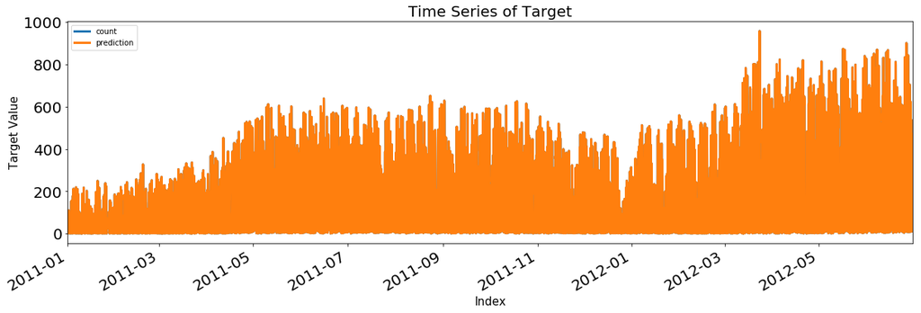

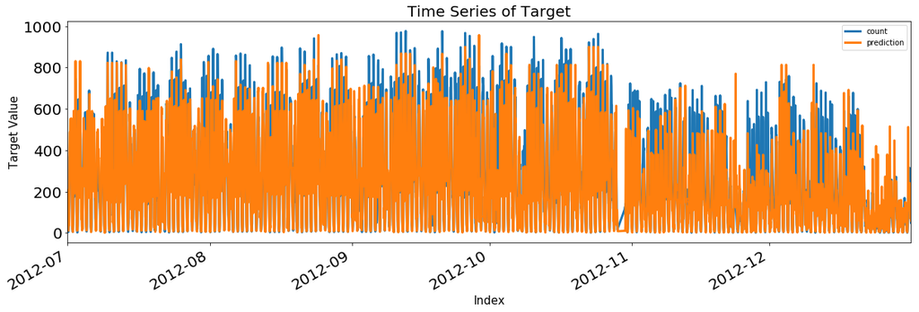

```python
Score7, Resid_tr_reg7, Resid_te_reg7 = Evaluation_TrTe(Y_train, model_pred_tr_reg7, Y_test, model_pred_te_reg7)
display(Score7)
Score8, Resid_tr_reg8, Resid_te_reg8 = Evaluation_TrTe(Y_train, model_pred_tr_reg8, Y_test, model_pred_te_reg8)
display(Score8)
Score9, Resid_tr_reg9, Resid_te_reg9 = Evaluation_TrTe(Y_train, model_pred_tr_reg9, Y_test, model_pred_te_reg9, graph_on=True)
display(Score9)
```

# Setting of Analysis

> **1. Import Library**  
> **2. Data Loading** [(Data Source and Description)](https://www.kaggle.com/c/bike-sharing-demand/data)  
> **3. Rearrange of Data**  
> **4. Split of Data: Train, Validate, Test Sets**  
> **5. Descriptive Statistics and Getting Insight from Features**  
> **6. Applying Models**  
> **7. Evaluation**  
> **8. Error Analysis**

```python
# # Error Analysis(Plot)
# Resid_tr_reg1['RowNum'] = Resid_tr_reg1.reset_index().index

# # Stationarity(Trend) Analysis
# sns.set(palette="muted", color_codes=True, font_scale=2)
# sns.lmplot(x='RowNum', y='Error', data=Resid_tr_reg1,
#            fit_reg='True', size=7, aspect=2, ci=99, sharey=True)

# # Normal Distribution Analysis
# figure, axes = plt.subplots(figsize=(16,8))
# sns.distplot(Resid_tr_reg1['Error'], norm_hist='True', fit=stats.norm)

# # Lag Analysis
# length = int(len(Resid_tr_reg1['Error'])/10)
# figure, axes = plt.subplots(3, 2, figsize=(16,16))
# pd.plotting.lag_plot(Resid_tr_reg1['Error'].iloc[1:length], lag=1, ax=axes[0,0])
# pd.plotting.lag_plot(Resid_tr_reg1['Error'].iloc[1:length], lag=2, ax=axes[0,1])
# pd.plotting.lag_plot(Resid_tr_reg1['Error'].iloc[1:length], lag=3, ax=axes[1,0])
# pd.plotting.lag_plot(Resid_tr_reg1['Error'].iloc[1:length], lag=4, ax=axes[1,1])
# pd.plotting.lag_plot(Resid_tr_reg1['Error'].iloc[1:length], lag=10, ax=axes[2,0])
# pd.plotting.lag_plot(Resid_tr_reg1['Error'].iloc[1:length], lag=20, ax=axes[2,1])

# # Autocorrelation Analysis
# figure, axes = plt.subplots(2,1,figsize=(16,10))
# figure = sm.graphics.tsa.plot_acf(Resid_tr_reg1['Error'].iloc[1:length], lags=100, use_vlines=True, ax=axes[0])
# figure = sm.graphics.tsa.plot_pacf(Resid_tr_reg1['Error'].iloc[1:length], lags=100, use_vlines=True, ax=axes[1])

# # Error Analysis(Statistics)
# # Checking Stationarity
# # Null Hypothesis: The Time-series is non-stationalry
# Stationarity = pd.Series(sm.tsa.stattools.adfuller(Resid_tr_reg1['Error'])[0:4], index=['Test Statistics', 'p-value', 'Used Lag', 'Used Observations'])
# for key, value in sm.tsa.stattools.adfuller(Resid_tr_reg1['Error'])[4].items():
#     Stationarity['Critical Value(%s)'%key] = value
# Stationarity['Maximum Information Criteria'] = sm.tsa.stattools.adfuller(Resid_tr_reg1['Error'])[5]
# Stationarity = pd.DataFrame(Stationarity, columns=['Stationarity'])

# # Checking of Normality
# # Null Hypothesis: The residuals are normally distributed
# Normality = pd.DataFrame([stats.shapiro(Resid_tr_reg1['Error'])], index=['Normality'], columns=['Test Statistics', 'p-value']).T

# # Checking for Autocorrelation
# # Null Hypothesis: Autocorrelation is absent
# Autocorrelation = pd.concat([pd.DataFrame(sm.stats.diagnostic.acorr_ljungbox(Resid_tr_reg1['Error'], lags=[1,5,10,50])[0], columns=['Test Statistics']),
#                              pd.DataFrame(sm.stats.diagnostic.acorr_ljungbox(Resid_tr_reg1['Error'], lags=[1,5,10,50])[1], columns=['p-value'])], axis=1).T
# Autocorrelation.columns = ['Autocorr(lag1)', 'Autocorr(lag5)', 'Autocorr(lag10)', 'Autocorr(lag50)']

# # Checking Heteroscedasticity
# # Null Hypothesis: Error terms are homoscedastic
# Heteroscedasticity = pd.DataFrame([sm.stats.diagnostic.het_goldfeldquandt(Resid_tr_reg1['Error'], X_train.values, alternative='two-sided')],
#                                   index=['Heteroscedasticity'], columns=['Test Statistics', 'p-value', 'Alternative']).T
# Error_Analysis = pd.concat([Stationarity, Normality, Autocorrelation, Heteroscedasticity], join='outer', axis=1)
# Error_Analysis = Error_Analysis.loc[['Test Statistics', 'p-value', 'Alternative', 'Used Lag', 'Used Observations',
#                                      'Critical Value(1%)', 'Critical Value(5%)', 'Critical Value(10%)',
#                                      'Maximum Information Criteria'],:]
# display(Error_Analysis)

# Error Analysis(Functionalize)
def Error_Analysis(Y_Data, Target_name, X_Data, graph_on=False):
    for x in Target_name:
        Target_name = x
    X_Data = X_Data.loc[Y_Data.index]

    if graph_on == True:
        ##### Error Analysis(Plot)
        Y_Data['RowNum'] = Y_Data.reset_index().index

        # Stationarity(Trend) Analysis
        sns.set(palette="muted", color_codes=True, font_scale=2)
        sns.lmplot(x='RowNum', y=Target_name, data=Y_Data, fit_reg='True', size=7, aspect=2, ci=99, sharey=True)

        # Normal Distribution Analysis
        figure, axes = plt.subplots(figsize=(16,8))
        sns.distplot(Y_Data[Target_name], norm_hist='True', fit=stats.norm)

        # Lag Analysis
        length = int(len(Y_Data[Target_name])/10)
        figure, axes = plt.subplots(3, 2, figsize=(16,16))
        pd.plotting.lag_plot(Y_Data[Target_name].iloc[1:length], lag=1, ax=axes[0,0])
        pd.plotting.lag_plot(Y_Data[Target_name].iloc[1:length], lag=2, ax=axes[0,1])
        pd.plotting.lag_plot(Y_Data[Target_name].iloc[1:length], lag=3, ax=axes[1,0])
        pd.plotting.lag_plot(Y_Data[Target_name].iloc[1:length], lag=4, ax=axes[1,1])
        pd.plotting.lag_plot(Y_Data[Target_name].iloc[1:length], lag=10, ax=axes[2,0])
        pd.plotting.lag_plot(Y_Data[Target_name].iloc[1:length], lag=20, ax=axes[2,1])

        # Autocorrelation Analysis
        figure, axes = plt.subplots(2,1,figsize=(16,10))
        figure = sm.graphics.tsa.plot_acf(Y_Data[Target_name].iloc[1:length], lags=100, use_vlines=True, ax=axes[0])
        figure = sm.graphics.tsa.plot_pacf(Y_Data[Target_name].iloc[1:length], lags=100, use_vlines=True, ax=axes[1])

    ##### Error Analysis(Statistics)
    # Checking Stationarity
    # Null Hypothesis: The Time-series is non-stationalry
    Stationarity = pd.Series(sm.tsa.stattools.adfuller(Y_Data[Target_name])[0:4],
                             index=['Test Statistics', 'p-value', 'Used Lag', 'Used Observations'])
    for key, value in sm.tsa.stattools.adfuller(Y_Data[Target_name])[4].items():
        Stationarity['Critical Value(%s)'%key] = value
        Stationarity['Maximum Information Criteria'] = sm.tsa.stattools.adfuller(Y_Data[Target_name])[5]
        Stationarity = pd.DataFrame(Stationarity, columns=['Stationarity'])

    # Checking of Normality
    # Null Hypothesis: The residuals are normally distributed
    Normality = pd.DataFrame([stats.shapiro(Y_Data[Target_name])],
                             index=['Normality'], columns=['Test Statistics', 'p-value']).T

    # Checking for Autocorrelation
    # Null Hypothesis: Autocorrelation is absent
    Autocorrelation = pd.concat([pd.DataFrame(sm.stats.diagnostic.acorr_ljungbox(Y_Data[Target_name], lags=[1,5,10,50])[0], columns=['Test Statistics']),
                                 pd.DataFrame(sm.stats.diagnostic.acorr_ljungbox(Y_Data[Target_name], lags=[1,5,10,50])[1], columns=['p-value'])], axis=1).T
    Autocorrelation.columns = ['Autocorr(lag1)', 'Autocorr(lag5)', 'Autocorr(lag10)', 'Autocorr(lag50)']

    # Checking Heteroscedasticity
    # Null Hypothesis: Error terms are homoscedastic
    Heteroscedasticity = pd.DataFrame([sm.stats.diagnostic.het_goldfeldquandt(Y_Data[Target_name], X_Data.values, alternative='two-sided')],
                                      index=['Heteroscedasticity'], columns=['Test Statistics', 'p-value', 'Alternative']).T
    Score = pd.concat([Stationarity, Normality, Autocorrelation, Heteroscedasticity], join='outer', axis=1)
    Score = Score.loc[['Test Statistics', 'p-value', 'Alternative', 'Used Lag', 'Used Observations',
                       'Critical Value(1%)', 'Critical Value(5%)', 'Critical Value(10%)', 'Maximum Information Criteria'],:]
    return Score
```

|  | Stationarity | Normality | Autocorr(lag1) | Autocorr(lag5) | Autocorr(lag10) | Autocorr(lag50) | Heteroscedasticity |
| --- | --- | --- | --- | --- | --- | --- | --- |
| Test Statistics | -17.5399 | 0.8463 | 1,578.0418 | 2,659.7878 | 2,994.9643 | 4,015.1028 | 1.5004 |
| p-value | 0.0000 | 0.0000 | 0.0000 | 0.0000 | 0.0000 | 0.0000 | 0.0000 |
| Alternative | nan | nan | nan | nan | nan | nan | two-sided |
| Used Lag | 23.0000 | nan | nan | nan | nan | nan | NaN |
| Used Observations | 12,979.0000 | nan | nan | nan | nan | nan | NaN |
| Critical Value(1%) | -3.4309 | nan | nan | nan | nan | nan | NaN |
| Critical Value(5%) | nan | nan | nan | nan | nan | nan | NaN |
| Critical Value(10%) | nan | nan | nan | nan | nan | nan | NaN |
| Maximum Information Criteria | 102,779.3620 | nan | nan | nan | nan | nan | NaN |

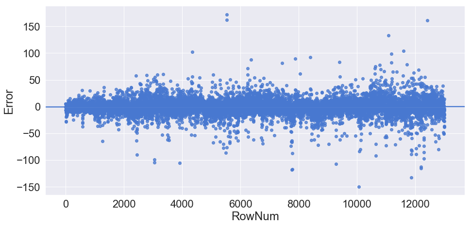

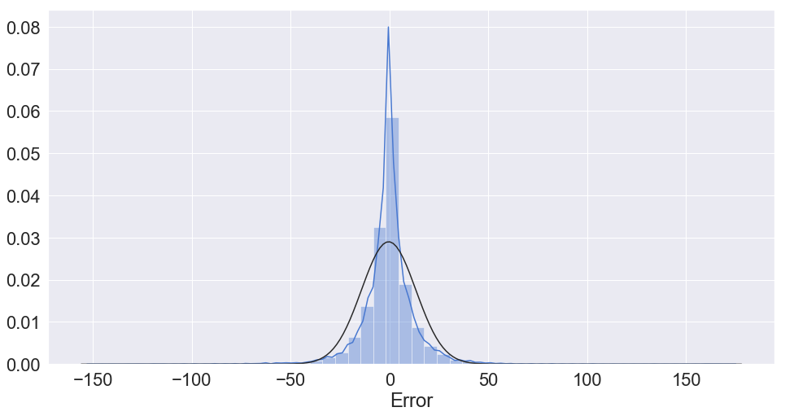

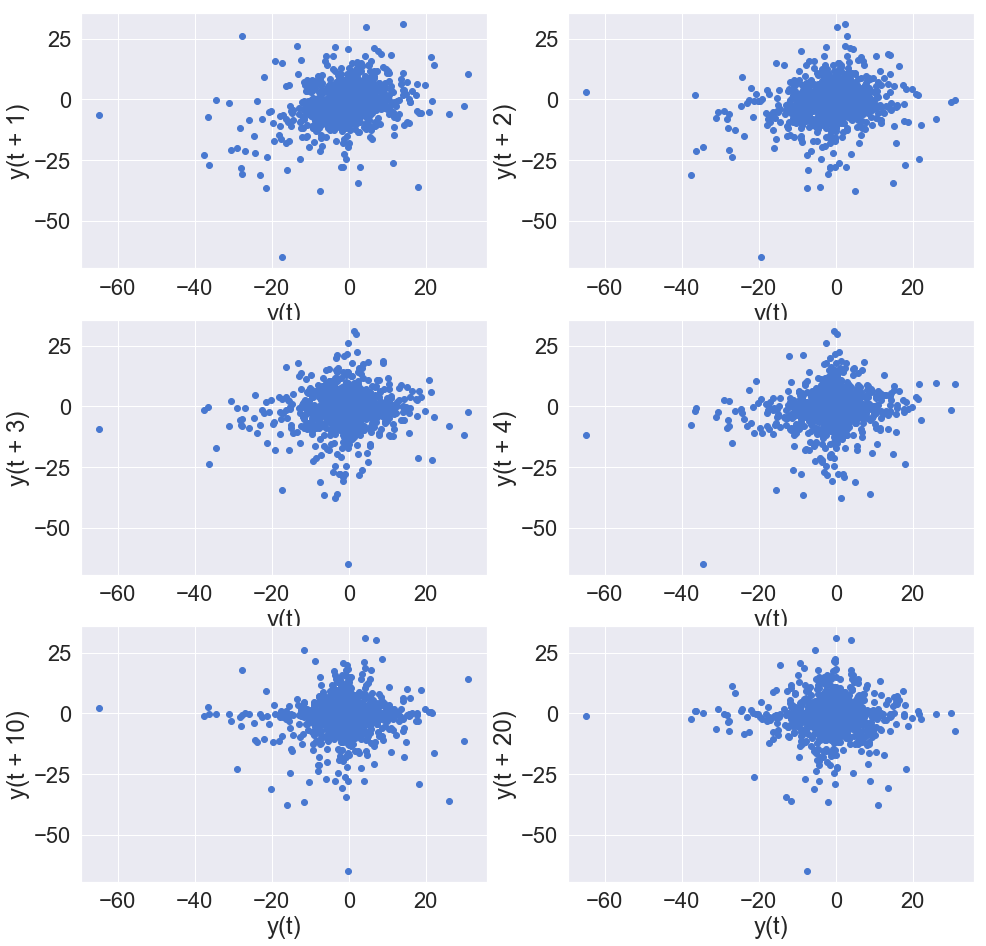

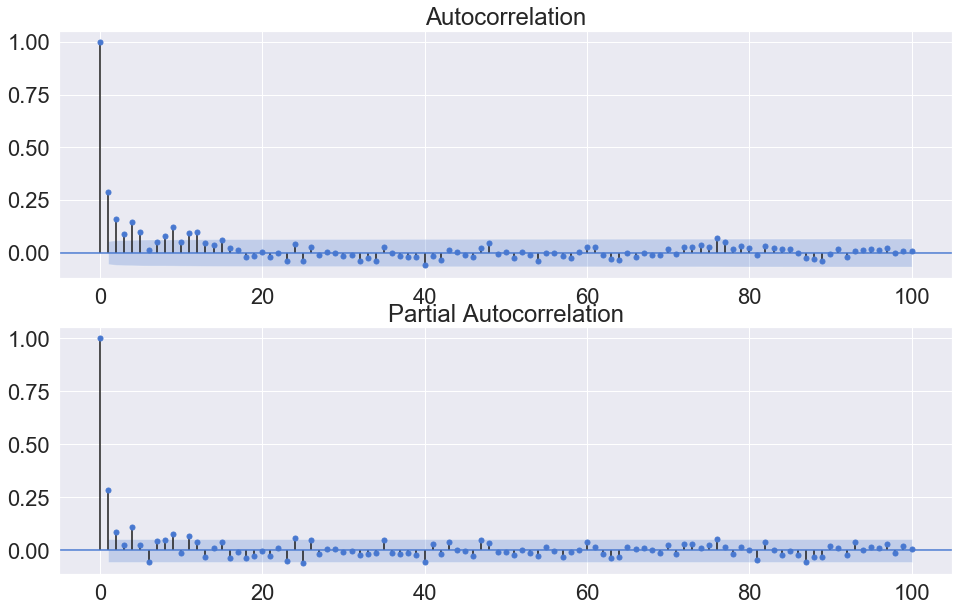

```python
Error_Analysis(Resid_tr_reg8, ['Error'], X_train, graph_on=True)
```